# Mini-projet - Partie 2

Régis Gourdel

Sun Mar 12 23:48:35 2017

*Initialisation de l’environnement :*

```r
rm(list = ls())
load('absc-Val.Rdata')
source('fonctions-miniprojet.R')
source('mesfonctions.R')
a = 2^(-16); b = 1.5
```

**2.1.a**

On affiche les estimations de l’intégrale de la fonction en zoomant sur la plage intéressante pour faire ensuite une estimation précise :

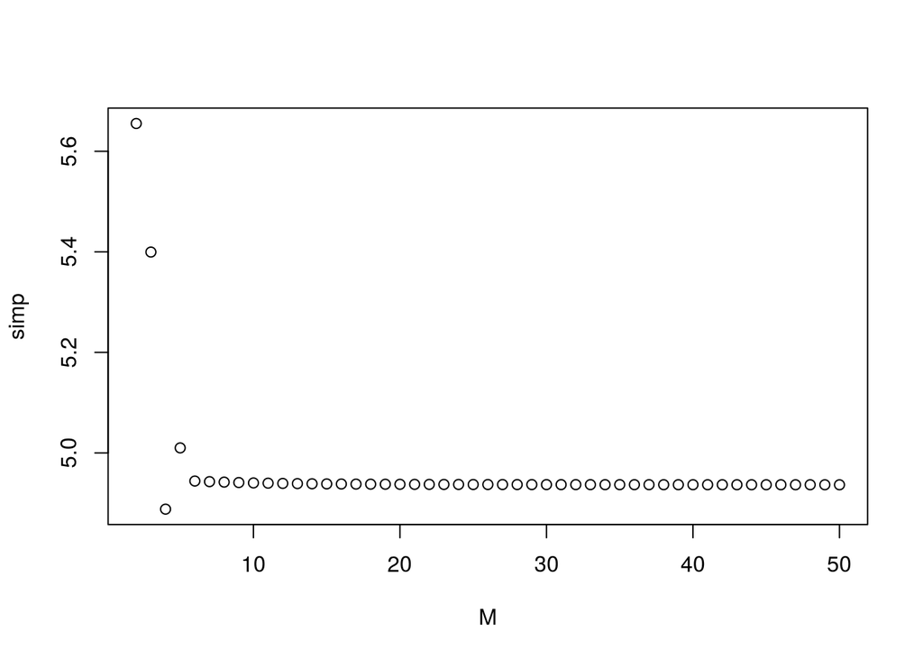

```r
M = seq(2,50,1)
simp = sapply(M, function(m) { simpsonInt(evalBoiteNoire, a, b, m) } )
plot(M, simp, type = 'p')
```

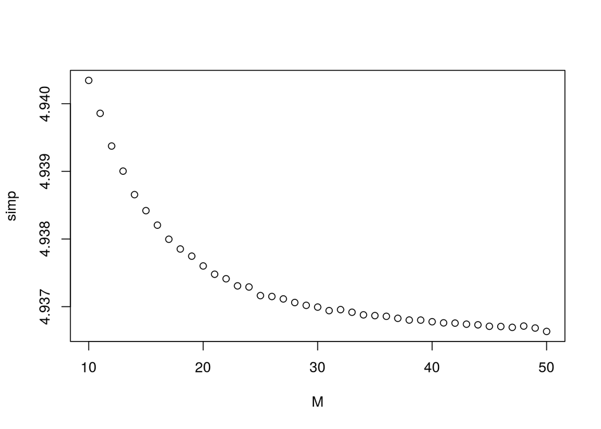

```r
M = seq(10,50,1)
simp = sapply(M, function(m) { simpsonInt(evalBoiteNoire, a, b, m) } )
plot(M, simp, type = 'p')
```

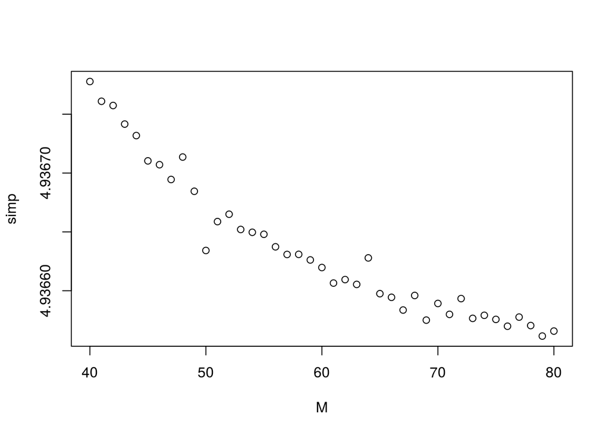

```r
M = seq(40,80,1)
simp = sapply(M, function(m) { simpsonInt(evalBoiteNoire, a, b, m) } )
plot(M, simp, type = 'p')
```

**2.1.b**

On a donc, à $10^{-3}$ près, $I \simeq 4{,}936$.

**2.2.a**

D’après la proposition 3.5.1, l’ordre de grandeur théorique de l’erreur en fonction de $h$ est $h^{N + 1}$ où $N$ est l’ordre de la méthode. Or ici la méthode de Cavalieri-Simpson est de rang 2, donc d’ordre $N = 3$.

On en déduit l’erreur $EI_{3,M}^{(a,b)} \propto h^4$.

**2.2.b**

On a, d’après la proposition 3.5.1 et le résultat précédent :
$$\log \left\vert I - \hat{I}_M^{simp} \right\vert = \log \left\vert EI_{3,M}^{(a,b)} \right\vert = \log \left\vert C^{te}_1 \cdot h^4 \right\vert = C^{te}_2 + 4 \cdot \log(h) = C^{te}_2 + 4 \cdot \log \left( \left( \frac{b - a}{M} \right)^4 \right) = C^{te}_3 - 4 \cdot \log(M)$$
d’où un graphe d’erreur log-log avec l’allure suivante :

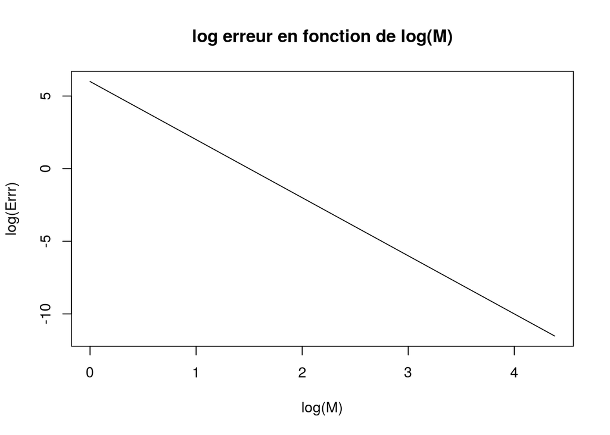

```r
M = seq(1,80)
plot(log(M), 6 - 4*log(M), type = 'l', main = "log erreur en fonction de log(M)", ylab = "log(Errr)")
```

**2.2.c**

On affiche l’erreur logarithmique avec ce qui suit :

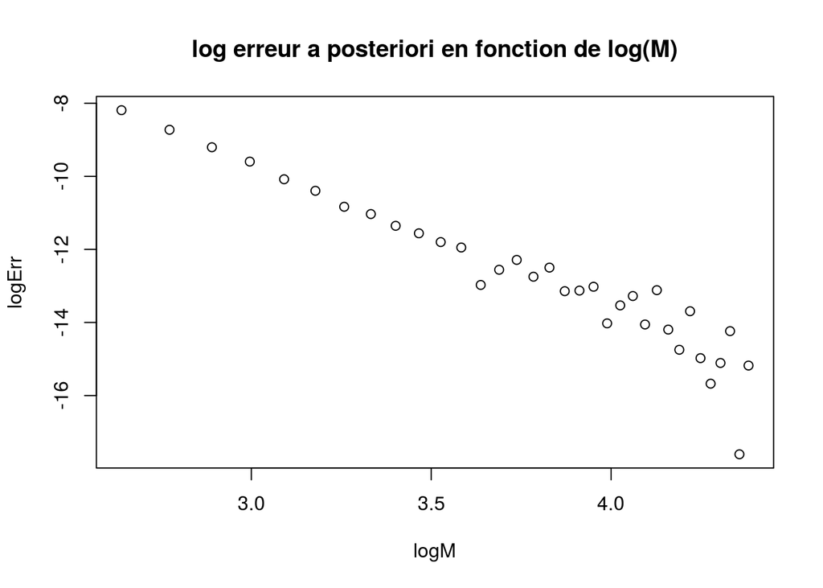

```r
M = seq(7,40)
vectErrorSimpson = rep(0, length(M))
for (i in 1:length(M)) {
  vectErrorSimpson[i] = abs( evalErrSimpson(evalBoiteNoire, a, b, M[i])[1] )
}
logM = log(2*M)
logErr = log(vectErrorSimpson)
plot(logM, logErr, type = 'p', main = 'log erreur a posteriori en fonction de log(M)')
```

On effectue une régression linéaire avec la fonction suivante :

```r
lm( logErr[1:10] ~ logM[1:10] )
```

```
##
## Call:
## lm(formula = logErr[1:10] ~ logM[1:10])
##
## Coefficients:
## (Intercept)   logM[1:10]
##       2.777       -4.150
```

On trouve donc une pente de $4{,}15$, ce qui est assez cohérent avec le résultat de $4$ prévu.

Le phénomène observé pour $M$ grand peut s’expliquer par le fait que les hypothèses faites dans le TD4 et sur lesquelles reposent l’évaluation de l’erreur a posteriori ne sont plus vérifiées ici. En effet avec un $M$ grand on peut supposer que les valeurs prises par $\xi_M$ connaissent des variations assez importantes.

**2.3.a**

On obtient les valeurs souhaitées par le code suivant :

```r
M = 10 ; erreur = 1 ; Mvecteur = 0 ; Qvecteur = 0 ; Evecteur = 0
tolerance = 10^(-5)
while (2*erreur > tolerance) {
  temp = evalErrSimpson(evalBoiteNoire, a, b, M)
  erreur = abs(temp[1])
  Evecteur = c(Evecteur, erreur)
  Qvecteur = c(Qvecteur, temp[2])
  Mvecteur = c(Mvecteur, M)
  M = 2*M
}
```

On affiche alors les résultats qui nous intéressent :

```r
Qvecteur
```

```
## [1] 0.000000 4.556707 4.556760
```

```r
Mvecteur
```

```
## [1]  0 10 20
```

```r
Iauto = Qvecteur[3]
Mauto = Mvecteur[3]
```

**4.a**

On trace le graphe log-log de l’écart en valeur absolue par la méthode de simpson à la valeur $I_{auto}$.

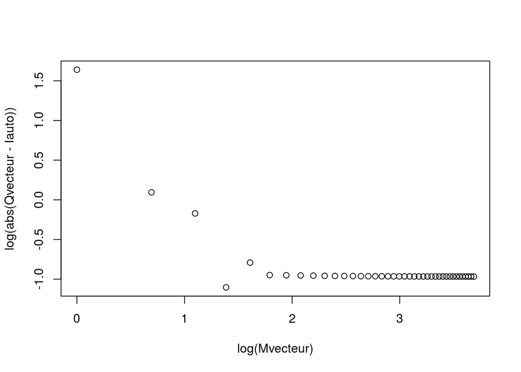

```r
Mvecteur = seq(1,40)
Qvecteur = rep(0,length(Mvecteur))
for (i in Mvecteur) {
  Qvecteur[i] = simpsonInt(evalBoiteNoire, a, b, i)
}
plot( log(Mvecteur), log(abs(Qvecteur - Iauto)) )
```

On s’attendait plutôt ici à trouver une erreur qui continue à décroître, alors qu’ici elle se stabilise.